# Reproducible Research:Peer Assessment 1

## Loading and preprocessing the data

###### Definition of common functions

```r
library(plyr)
library(ggplot2)
library(xtable)
mean.calculation <- function (a){
    meanPerInterval <- aggregate(x = a$steps, by = list(factor(a$interval)), FUN = "mean")
    # add column names
    colnames(meanPerInterval) <- c("interval","totalSteps")
    # convert interval to a numeric and split into hours and minutes
    meanPerInterval$interval <- as.numeric(as.character(meanPerInterval$interval))
    rownames(meanPerInterval) <- meanPerInterval$interval
    h <- as.integer(meanPerInterval$interval/100)
    m <- meanPerInterval$interval - h*100
    # calculate interval as fractional hours (needed to make plots uniform in time)
    fInterval <- h+m/60
    meanPerInterval <- cbind(meanPerInterval,fInterval)
    return (meanPerInterval)
}
```

###### NOTE ON TIME SCALING

The time of day is in HH:MM format. If meanPerInterval is plotted directly agains HH:MM it results in a distortion since because of the 60 minutes. The function mean.calculation normalizes the time to fractional hours. This is only a correction needed for plotting.

###### Read raw data

```r
unzip("activity.zip")
activity <- read.csv("activity.csv")
```

###### Create data frame with NA removed

```r
ac <- activity[!is.na(activity$steps),]
```

## What is mean total number of steps taken per day?

```r
totalPerDay <- aggregate(x = ac$steps, by = list(factor(ac$date)), FUN = "sum")
colnames(totalPerDay) <- c("Date","TotalSteps")
```

###### Total number of steps taken per day

```r
print(xtable(totalPerDay), type='html')
```

|  | Date | TotalSteps |
| --- | --- | --- |
| 1 | 2012-10-02 | 126 |
| 2 | 2012-10-03 | 11352 |
| 3 | 2012-10-04 | 12116 |
| 4 | 2012-10-05 | 13294 |
| 5 | 2012-10-06 | 15420 |
| 6 | 2012-10-07 | 11015 |
| 7 | 2012-10-09 | 12811 |
| 8 | 2012-10-10 | 9900 |
| 9 | 2012-10-11 | 10304 |
| 10 | 2012-10-12 | 17382 |
| 11 | 2012-10-13 | 12426 |
| 12 | 2012-10-14 | 15098 |
| 13 | 2012-10-15 | 10139 |
| 14 | 2012-10-16 | 15084 |
| 15 | 2012-10-17 | 13452 |
| 16 | 2012-10-18 | 10056 |
| 17 | 2012-10-19 | 11829 |
| 18 | 2012-10-20 | 10395 |
| 19 | 2012-10-21 | 8821 |
| 20 | 2012-10-22 | 13460 |
| 21 | 2012-10-23 | 8918 |
| 22 | 2012-10-24 | 8355 |
| 23 | 2012-10-25 | 2492 |
| 24 | 2012-10-26 | 6778 |
| 25 | 2012-10-27 | 10119 |
| 26 | 2012-10-28 | 11458 |
| 27 | 2012-10-29 | 5018 |
| 28 | 2012-10-30 | 9819 |
| 29 | 2012-10-31 | 15414 |
| 30 | 2012-11-02 | 10600 |
| 31 | 2012-11-03 | 10571 |
| 32 | 2012-11-05 | 10439 |
| 33 | 2012-11-06 | 8334 |
| 34 | 2012-11-07 | 12883 |
| 35 | 2012-11-08 | 3219 |
| 36 | 2012-11-11 | 12608 |
| 37 | 2012-11-12 | 10765 |
| 38 | 2012-11-13 | 7336 |
| 39 | 2012-11-15 | 41 |
| 40 | 2012-11-16 | 5441 |
| 41 | 2012-11-17 | 14339 |
| 42 | 2012-11-18 | 15110 |
| 43 | 2012-11-19 | 8841 |
| 44 | 2012-11-20 | 4472 |
| 45 | 2012-11-21 | 12787 |
| 46 | 2012-11-22 | 20427 |
| 47 | 2012-11-23 | 21194 |
| 48 | 2012-11-24 | 14478 |
| 49 | 2012-11-25 | 11834 |
| 50 | 2012-11-26 | 11162 |
| 51 | 2012-11-27 | 13646 |
| 52 | 2012-11-28 | 10183 |
| 53 | 2012-11-29 | 7047 |

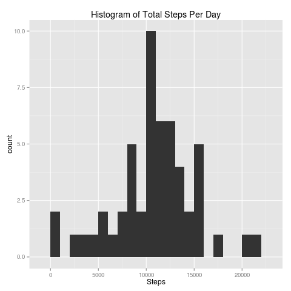

```r
png(file="figures/histogram.png",width=480,height=480)
phist <- ggplot(totalPerDay, aes(x=TotalSteps)) + geom_histogram(binwidth=1000)
phist+xlab("Steps")+ggtitle("Histogram of Total Steps Per Day")
invisible(dev.off())
```

```r
meanSteps <- sprintf("%0.f",mean(totalPerDay$TotalSteps))
medianSteps <- sprintf("%0.f",median(totalPerDay$TotalSteps))
```

###### Mean of number of steps per day : 10766

###### Median of number of steps per day : 10765

## What is the average daily activity pattern?

#### The average number of steps taken in 5-minute intervals, averaged across all days

```r
meanPerInterval <- mean.calculation(ac)
```

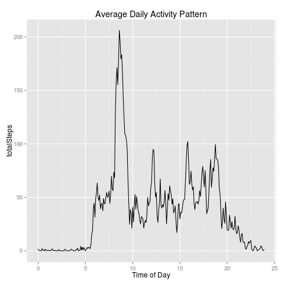

```r
png(file="figures/average.png",width=480,height=480)
gp <- ggplot(meanPerInterval, aes(x=fInterval, y=totalSteps)) + geom_line()
gp + xlab("Time of Day") + ggtitle("Average Daily Activity Pattern")
invisible(dev.off())
```

#### Locate the maximum number of average steps and the interval in which it occurs

```r
#maxAverageSteps <- sprintf("%0.f",max(meanPerInterval$totalSteps))
maxAverageSteps <- max(meanPerInterval$totalSteps)
maxStepsAt <- subset(meanPerInterval,subset=(meanPerInterval$totalSteps==maxAverageSteps))$interval
```

###### Max average number of steps: 206

###### Interval in which it occur: 835

## Imputing missing values

```r
naindex <- which(is.na(activity)==TRUE)
nNa <- length(naindex)
```

###### The total number of missing values in the dataset: 2304

#### Create data frame with imputed missing values

###### Imputing strategy

Replace NA with the mean value of the corresponding 5 minute slot

```r
# Copied from post: https://class.coursera.org/repdata-004/forum/thread?thread_id=82
# Thank You, Greg Tyler
# Function to replace NA by value from a data frame
# technique to replace NA with mean by subset in R and the impute.mean function
# described at http://stackoverflow.com/a/9322975/3657371

# create a new dataset that is equal to the original dataset, but with the
# missing data filled in

impute.mean <- function(x) replace(x, is.na(x), mean(x, na.rm = TRUE))
activity.imputed <- plyr::ddply(activity[1:3], .(interval), transform,
                                steps = impute.mean(steps),
                                date = date,
                                interval = interval)
# sort by date and interval
activity.imputed <- activity.imputed[order(activity.imputed$date,
                                           activity.imputed$interval),]
```

###### First 6 rows of the activity df with imputed NA

```r
print (xtable(head(activity.imputed)),type="html")
```

|  | steps | date | interval |
| --- | --- | --- | --- |
| 1 | 1.72 | 2012-10-01 | 0 |
| 62 | 0.34 | 2012-10-01 | 5 |
| 123 | 0.13 | 2012-10-01 | 10 |
| 184 | 0.15 | 2012-10-01 | 15 |
| 245 | 0.08 | 2012-10-01 | 20 |
| 306 | 2.09 | 2012-10-01 | 25 |

## What is mean total number of steps taken per day?

```r
ai <- activity.imputed
totalPerDayi <- aggregate(x = ai$steps, by = list(factor(ai$date)), FUN = "sum")
colnames(totalPerDayi) <- c("Date","TotalSteps")
```

#### Total number of steps taken per day

```r
print (xtable(totalPerDayi),type='html')
```

|  | Date | TotalSteps |
| --- | --- | --- |
| 1 | 2012-10-01 | 10766.19 |
| 2 | 2012-10-02 | 126.00 |
| 3 | 2012-10-03 | 11352.00 |
| 4 | 2012-10-04 | 12116.00 |
| 5 | 2012-10-05 | 13294.00 |
| 6 | 2012-10-06 | 15420.00 |
| 7 | 2012-10-07 | 11015.00 |
| 8 | 2012-10-08 | 10766.19 |
| 9 | 2012-10-09 | 12811.00 |
| 10 | 2012-10-10 | 9900.00 |
| 11 | 2012-10-11 | 10304.00 |
| 12 | 2012-10-12 | 17382.00 |
| 13 | 2012-10-13 | 12426.00 |
| 14 | 2012-10-14 | 15098.00 |
| 15 | 2012-10-15 | 10139.00 |
| 16 | 2012-10-16 | 15084.00 |
| 17 | 2012-10-17 | 13452.00 |
| 18 | 2012-10-18 | 10056.00 |
| 19 | 2012-10-19 | 11829.00 |
| 20 | 2012-10-20 | 10395.00 |
| 21 | 2012-10-21 | 8821.00 |
| 22 | 2012-10-22 | 13460.00 |
| 23 | 2012-10-23 | 8918.00 |
| 24 | 2012-10-24 | 8355.00 |
| 25 | 2012-10-25 | 2492.00 |
| 26 | 2012-10-26 | 6778.00 |
| 27 | 2012-10-27 | 10119.00 |
| 28 | 2012-10-28 | 11458.00 |
| 29 | 2012-10-29 | 5018.00 |
| 30 | 2012-10-30 | 9819.00 |
| 31 | 2012-10-31 | 15414.00 |
| 32 | 2012-11-01 | 10766.19 |
| 33 | 2012-11-02 | 10600.00 |
| 34 | 2012-11-03 | 10571.00 |
| 35 | 2012-11-04 | 10766.19 |
| 36 | 2012-11-05 | 10439.00 |
| 37 | 2012-11-06 | 8334.00 |
| 38 | 2012-11-07 | 12883.00 |
| 39 | 2012-11-08 | 3219.00 |
| 40 | 2012-11-09 | 10766.19 |
| 41 | 2012-11-10 | 10766.19 |
| 42 | 2012-11-11 | 12608.00 |
| 43 | 2012-11-12 | 10765.00 |
| 44 | 2012-11-13 | 7336.00 |
| 45 | 2012-11-14 | 10766.19 |
| 46 | 2012-11-15 | 41.00 |
| 47 | 2012-11-16 | 5441.00 |
| 48 | 2012-11-17 | 14339.00 |
| 49 | 2012-11-18 | 15110.00 |
| 50 | 2012-11-19 | 8841.00 |
| 51 | 2012-11-20 | 4472.00 |
| 52 | 2012-11-21 | 12787.00 |
| 53 | 2012-11-22 | 20427.00 |
| 54 | 2012-11-23 | 21194.00 |
| 55 | 2012-11-24 | 14478.00 |
| 56 | 2012-11-25 | 11834.00 |
| 57 | 2012-11-26 | 11162.00 |
| 58 | 2012-11-27 | 13646.00 |
| 59 | 2012-11-28 | 10183.00 |
| 60 | 2012-11-29 | 7047.00 |
| 61 | 2012-11-30 | 10766.19 |

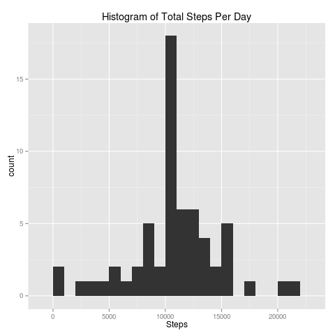

```r
png(file="figures/histogrami.png",width=480,height=480)
phist <- ggplot(totalPerDayi, aes(x=TotalSteps)) + geom_histogram(binwidth=1000)
phist+xlab("Steps")+ggtitle("Histogram of Total Steps Per Day")
invisible(dev.off())
```

```r
meanStepsi <- sprintf("%0.f",mean(totalPerDayi$TotalSteps))
medianStepsi <- sprintf("%0.f",median(totalPerDayi$TotalSteps))
```

###### Mean of number of steps per day : 10766

###### Median of number of steps per day : 10766

#### ANALYSIS

No significant difference between data with NA removed and data with imputed values in place of NA

## Are there differences in activity patterns between weekdays and weekends?

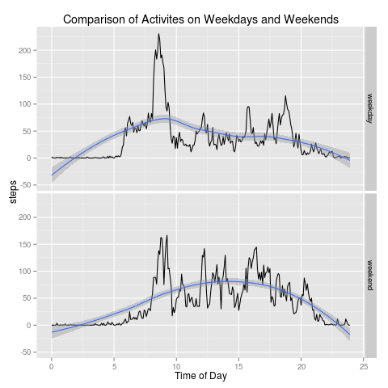

```r
wd <- factor(as.POSIXlt(ai$date)$wday %in% c(0,6),labels=c("weekday","weekend"))
ai1<-cbind(ai,dayType = wd)
a.weekend <- subset(ai1,subset=ai1$dayType=="weekend")
a.weekday <- subset(ai1,subset=ai1$dayType=="weekday")
meanPerInterval.weekend <- mean.calculation(a.weekend)
meanPerInterval.weekday <- mean.calculation(a.weekday)
meanPerInterval.weekend <- cbind(meanPerInterval.weekend,c("weekend"))
meanPerInterval.weekday <- cbind(meanPerInterval.weekday,c("weekday"))
colnames(meanPerInterval.weekend)<-c("interval","steps","fInterval","dayType")
colnames(meanPerInterval.weekday)<-c("interval","steps","fInterval","dayType")
meanPerInterval.both <- rbind(meanPerInterval.weekday,meanPerInterval.weekend)
png(file="figures/week.days.end.png",width=480,height=480)
p<-ggplot(meanPerInterval.both, aes(x=fInterval, y=steps)) + geom_line()+geom_smooth(method=loess)+ggtitle("Comparison of Activites on Weekdays and Weekends")+xlab("Time of Day")
p+facet_grid(dayType~.)

invisible(dev.off())
```